# *Problems of Philosophy*, Chapter 9

Philosophy 101 - Class 09

Brian Weatherson

weath@umich.edu

University of Michigan

September 26, 2023

# Assignment Recap

## Adjustments

I gave credit to the most common incorrect answers in questions 1 and 18. Question 18 I think there is a way to read one of the ‘wrong’ answers so it was actually correct, so that’s a bad question, and I should have caught that. Question 1 I think was right the first way, but it was pretty hard first up.

Do you think your local butcher will reduce the amount of meat she orders from the slaughterhouse if you become a vegetarian? Of course not! The supply chain for meat just isn’t sensitive to the quantities that a single person consumes. So, by becoming a vegetarian, you’ll never save a single animal’s life! But by becoming a vegetarian, you’ll deprive yourself of the pleasure of eating meat, and you should only do that if the benefits would outweigh the losses. Therefore, you should only become a vegetarian if doing so would save some animals’ lives.

QUESTION: What is the conclusion of this argument?

1. You should only become vegetarian if doing so would save animals’ lives.
2. You shouldn’t become a vegetarian.
- On the one hand, 1 is what it literally says after therefore.
- On the other hand, the person making this speech is clearly aiming for 2.
- As a general rule, if someone is clearly arguing for *A*, they are not merely aiming to argue for *If A, then X*.
- They want you to combine this with *A* to get *X*.
- So I think the person making this argument wants the stronger claim, don’t be vegeterian, not the weaker claim, don’t be vegetarian if…
- But it’s hard so I gave both full marks.

Question 8

I don’t think that humans should become biologically immortal. Due to natural selection and the process of evolution, each new generation of humans is slightly better adapted to survive than the one before it. If an entire generation were to become biologically immortal, this process would basically stagnate. Any future generations would have to be very small (or even nonexistent), because if there were a much lower death rate, we would have to limit the number of people born in order to preserve resources. Biological immortality would essentially stunt the evolutionary development of the entire human race.

QUESTION: Which of the following is used to directly support the claim “biological immortality would stunt the evolutionary development of the entire human race”?

1. If humans became biologically immortal, future generations would have to be very small or even nonexistent.
2. If an entire generation were to become biologically immortal, the evolutionary process would stagnate.
- The short version here is that 2 is close to synonymous with the conclusion.
- A really common form of writing is to say “Conclusion. Here’s why to believe conclusion. Restated conclusion.”
- And that’s what is going on here.
- I don’t think 2 is used to support anything because at the point it comes up, 2 isn’t supported by anything; it’s supported by what comes after.
- So that’s the form of writing used.
- And to be clear, this is a perfectly fine form of writing. It’s not maximally efficient, but it can be clear in the way that maximally efficient writing isn’t. (I’m not sure it’s good here; but it can be good.)

Question 10

I don’t think that humans should become biologically immortal. Due to natural selection and the process of evolution, each new generation of humans is slightly better adapted to survive than the one before it. If an entire generation were to become biologically immortal, this process would basically stagnate. Any future generations would have to be very small (or even nonexistent), because if there were a much lower death rate, we would have to limit the number of people born in order to preserve resources. Biological immortality would essentially stunt the evolutionary development of the entire human race.

QUESTION: What is assumed when the claim “if there is a much lower death rate, we would have to limit the number of people born in order to preserve resources” is used to support the claim that if humans became biologically immortal, future generations would have to be very small or even nonexistent?

- This was really hard. Only one where didn’t have majority correct.
- It’s worth stepping back a bit to get a big picture of what’s going on.
- Both premise and conclusion here are conditionals, they are of the form $X \rightarrow Y$.
- Call the premise $B \rightarrow C$, and the conclusion $A \rightarrow D$.
- Then what’s needed to get from premise to conclusion is $A \rightarrow B$ and $C \rightarrow D$.
- It’s worth pausing for a minute to think about why.

Now let’s fill in the details

- $A$ (the ‘if’ part of the conclusion) is *Humans become biologically immortal*.
- $B$ (the ‘if’ part of the premise) is *There is a much lower death rate*.
- $C$ (the ‘then’ part of the premise) is *We have to limit the number of people born in order to preserve resources*.
- $D$ (the ‘then’ part of the conclusion) is *Future generations would have to be very small or even nonexistent*.

And the assumptions are $A \rightarrow B$, and $C \rightarrow D$.

- I guess they were thinking that $C \rightarrow D$ is kind of trivial, so $A \rightarrow B$ is the real assumption. That’s slightly questionable to me, but since $C \rightarrow D$ wasn’t an option, $A \rightarrow B$ is the best answer.

## Assumptions

Then there were a few (12, 15, and 20) where people had problems with assumptions.

- A lot of the time, people gave an answer that was either a restatement of the premise, or one of the earlier support lines.
- The big thing to ask yourself about an assumption:
- If I rejected this assumption, would I think that *step* is terrible.
- Let’s do an example of that.

As nice as free college for everyone sounds, we shouldn’t let the state fund college education. First of all, that would be expensive for the state, and expensive state-funded programs often result in resources being thinly spread. So, with resources spread so thin, the quality of education offered would definitely suffer. More importantly, we don’t want the state to be in control of what we learn! If that were the case, then they could stop any criticism of the government and only promote their own ideas. That goes against the very essence of democracy!

QUESTION: What is assumed when the claim “state-funded education suffers in quality” is used to support the claim that we should not let the state fund college education?

ANSWER: We should not lower the quality of education.

The test.

- Assume you believe it’s false that “We should not lower the quality of education”. I.e., you believe we should lower the quality of education. (Not so easy even if you try.)
- How does the step from *State education suffers in quality* to *We should not let the state fund college education* look?
- It looks terrible!
- From this background, that state education suffers in quality is a reason **in favor** of the state funding college education.

The test and a rival answer: Lack of resources leads to lower quality education.

- Assume you believe it’s false that “Lack of resources leads to lower quality education.”. I.e., you believe lack of resources does not lead to lower quality education. (Imagine thinking that at the margin, we waste tons of resources, and get no quality gain.)
- How does the step from *State education suffers in quality* to *We should not let the state fund college education* look?
- It looks fine!
- The background gives you reason to reject the premise, but not the step from the premise to the conclusion.

# Metaphysics

## The Big Question

What is in the world?

**ALERT**: iClicker quiz on next slide.

## iClicker Quiz

What is Russell’s view on universals?

1. They don’t exist.
2. They exist but are mind-dependent.
3. They exist are are mind-independent.

## The World of Things

One of the points of chapter 9 is to argue that the world doesn’t consist of just things.

Things aren’t enough to explain all the facts.

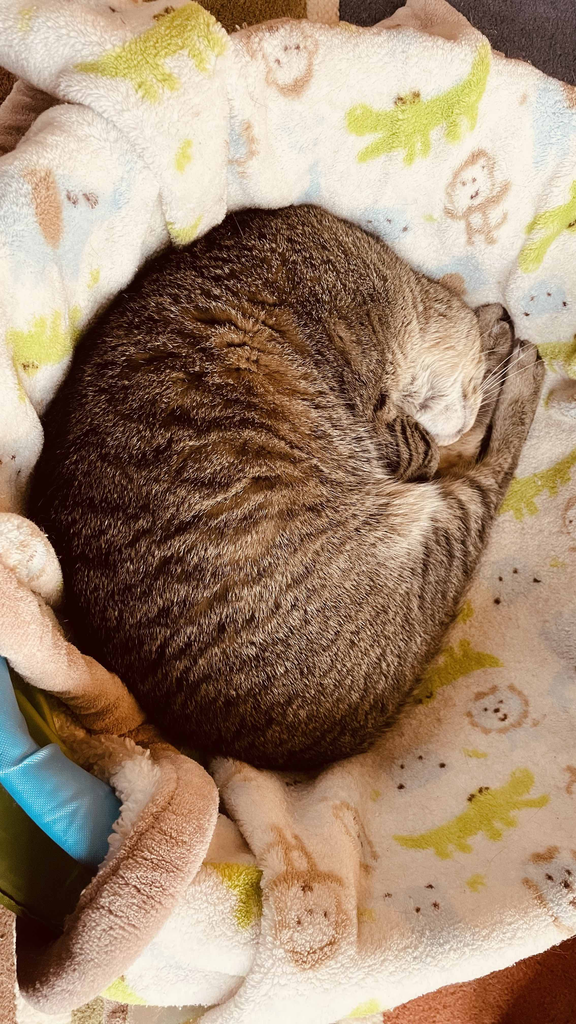

Squid, asleep

*Squid is sleeping* isn’t just made true by what exists (i.e., Squid), but by how it exists.

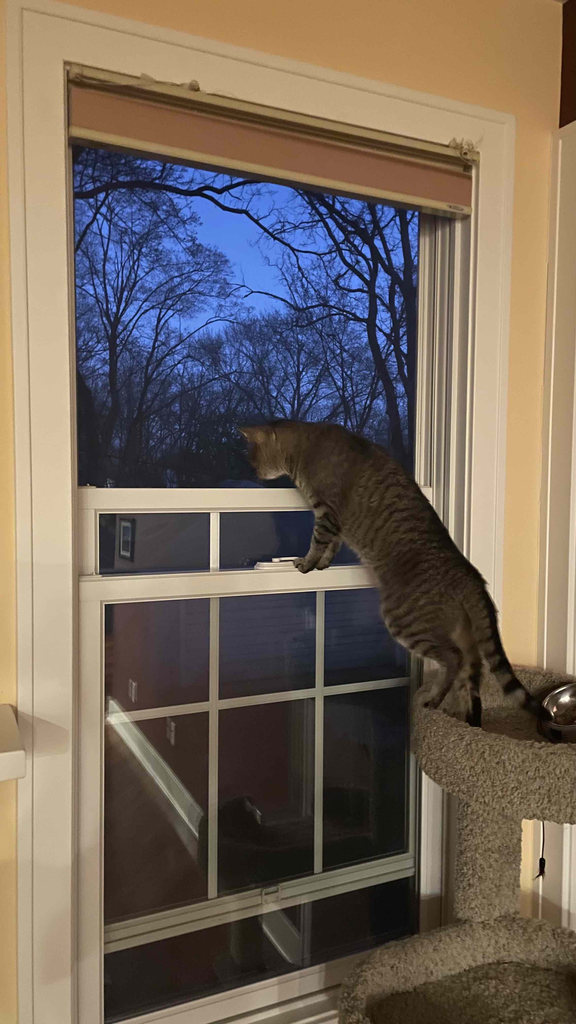

Squid, in a tree

*Squid loves Tree*, where Tree is a name for that tree Squid is standing in, isn’t just made true by what exists (i.e., Squid and Tree), but by how they exist.

We need universals like SLEEPING and LOVES to be part of our metaphysics.

[figure not shown]

Plato

Plato (420s-348 BCE) argued that forms exist outside space and time, and ground universals.

[figure not shown]

Aristotle

Aristotle (384-322 BCE) agreed that universals are real and mind-independent, but denied they were independent of their bearers.

[figure not shown]

Abelard

Peter Abelard (1079-1142) argued for nominalism, the view that we just have general words, but there are no universals.

Abelard is shown here with his sometime lover Héloïse, and if you don’t know the story of Abelard and Héloïse you probably should. Though be warned it gets a bit gory by the end.

# Doing Without Universals

## Two Attempts

### There are others too, but we’ll focus on two

1. Objects and resemblances (which we project)
2. Sets of objects

## Resemblance

There are just things like Squid, and Tree, and you and me. There is no SLEEPING or LOVES.

It’s just that we humans, perhaps for good practical reasons, project patterns we see onto the world.

## Russell’s Objection to This

What does it mean to say that something else **resembles** the paradigm of a sleeping thing.

That looks like a universal too.

To say that to be sleeping just is to resemble our paradigm of a sleeper is not to remove universals; it’s to replace a universal property (like SLEEPING) with a universal relation (like RESEMBLES)

## Sets

A more modern approach is to say that there are just objects, and sets of objects.

More or less equivalently, we can say that there are objects, and two truth values (T and F), and functions from things we recognise into things we recognise.

So a predicate, like ‘is sleeping’ or ‘is cute’ is a function from things to truth values; intuitively, the things that have the property are mapped to T and everything else to F.

## Semantics

This is actually the start of a rather nice theory of word meanings, and one you might study a bit more in other philosophy or linguistics classes.

One advantage is that it generalises nicely. Think about the (true) sentence *Squid is very cute*.

Russell would say that ‘Squid’ picks out Squid, and ‘cute’ picks out CUTENESS, but what does ‘very’ pick out? Is there a universal of VERYNESS?

## Semantics

Here’s a nice theory. ‘Very’ is a function from predicate meanings to predicate meanings. (Where a predicate meaning is a function from objects to truth values) In a sentence it says “Give me a predicate, and I’ll give you a new predicate”.

What’s the structure of that function? Well, it returns a new predicate that only says T to things that are really solid cases of T in the original.

This isn’t a semantics class, but this idea of treating all words (except names) as functions of more or less complexity is rather elegant.

## Metaphysics

But we’re going to focus on metaphysics, not semantics.

Instead of the universals that Russell posits, could we just have sets?

## Relations

Russell’s big concern is that a lot of other theories don’t have place for relations.

But the sets theory does.

A relation is just a set of ordered pairs.

And an ordered pair is just, well it’s something a bit like a set.

## Problems

1. Sets are spooky.
2. There are too many sets.

## Spooky

The people who think that we should do away with universals and just have sets typically think that there is something mysterious, spooky, about these Platonic universals.

But sets are just as weird, as becomes clear as soon as you think about **singletons**, i.e., sets with just one member.

Squid’s singleton is not identical to Squid, but it isn’t anywhere other than where Squid is. It seems a really odd thing to have to posit, just as mysterious as a universal like SLEEPING.

## Too Many

But the big problem is that there are too many sets.

- There is a set of all the things that are sleeping.
- But there is also a set of all the things that are sleeping plus this remote control.
- And there is a set of all the things that are sleeping *except Squid*.
- These cause all sorts of problems.

## Problems from Abundance

The vast number of sets causes all sorts of challenges.

- How do we learn ‘sleeeping’ means this particular set not some nearby one?
- That Squid is sleeping **explains** some things. That Squid is in a set doesn’t explain anything, because set-membership is cheap.
- That Squid is sleeping implies she resembles, in some respect, other sleeping things. But common set-membership does not imply resemblance, since any two things no matter how disjoint are in a set together.

# Some Questions about Universals

## Abundant or Sparse

- Russell seems to think that there are *lots* of universals; maybe one for each word.
- That’s not a common view these days.
- It’s more common to say that there are a handful of universals.
- In particular, there are only as many universals as are needed to explain facts of resemblance.

## Abundant or Sparse

Indeed, for some contemporary(ish) defenders of universals, explaining resemblance is **the job** that universals do.

The Australian philosopher David Armstrong, who for a while was the most prominent defender of (something like) the theory of universals Russell endorses, thought there were exactly as many universals as were needed to explain resemblance between objects.

## Abundant or Sparse

But you don’t need universals for every predicate to do that. You certainly don’t need them for compound predicates.

So, it being fall, think about the predicate in *This is a pumpkin spice latte*.

It’s (somewhat) plausible that PUMPKIN, SPICE, and LATTE are all universals.

But we don’t need another universal PUMPKIN SPICE LATTE to explain what all pumpkin spice lattes have in common. We can do that by explaining that they are all lattes, and that they are all pumpkin spiced.

## Very Tricky Question

The pumpkin spice latte raises a problem that I’m just going to mention, and then leave for metaphysics classes.

In that phrase, ‘pumpkin’ does not immediately modify ‘latte’, it modifies ‘spice’. It tells you what kind of spice is in the drink.

You might ask, as a sort of metaphysical parallel to that, whether universals themselves can have properties.

## Very Tricky Question

On the one hand yes sure of course they do: HONESTY is a virtue, for example.

On the other hand, the logical and metaphysical troubles that arise when you allow this are immense, and it’s really hard to not contradict yourself if you go this way.

(The problems start with things like the property of being a property that doesn’t apply to itself. That’s very much not our problem today.)

What’s called *higher-order metaphysics* is about this, among other questions.

## Universals Everywhere

Russell says that every sentence has a universal in it.

- Here’s a tricky case for that: *Peter Parker is Spiderman*.
- If you don’t like fictional examples, use *Onika Tanya Maraj-Petty is Nicki Minaj*.
- That’s true, and it does have a verb in it.
- Is that a universal? I think Russell would say yes.
- But the ‘is’ there is identity, and being self-identical is not a way in which Spiderman resembles anything, since everything is self-identical.

## Immanent or Platonic

Russell says that universals have being but not existence, because they aren’t in the world.

There’s a rival view (held by Armstrong, following Aristotle) that universals are indeed in the world, and they are (in some sense) in the things that instantiate them.

So HUMANITY isn’t something that has being in Platonic heaven, it’s in this room (and many other rooms).

I’m mostly just flagging this as an interesting (and *long*-running) debate that arises around here.

## Mind-Dependent

Russell is very concerned to argue that universals represent mind-independent facts about reality.

But the example he uses for this is completely wild, and doesn’t really make the point.

> Edinburgh is north of London.

## Mind-Dependent

I think cities, like Edinburgh and London, are mind-dependent entities.

- I don’t just mean that they were caused to come into being by minds, though that’s true.
- Nor do I just mean that the fact that “London” means London is something that is mind-dependent, though that’s true too.
- I mean what London itself is is mind-dependent, and the same goes for all other cities.

## Ann Arbor

Where is Ann Arbor? The boundaries are of course written down in a rulebook somewhere, but what makes them the boundaries.

I think it’s the fact that we all agree that those regulations are the ones that matter. And *agreeing* is a thing that minds do.

## Ann Arbor

If we **all** came to believe that UM was in a separate city from Ann Arbor, perhaps a new city called Wolverineville, that would kind of do it; Ann Arbor would no longer contain UM.

- The metaphysics of cities I think is really hard, and the toy theory Russell has, that ‘London’ names a point on the earth’s surface, isn’t actually that plausible.
- It’s conceptually possible that London is 10 miles west of where it used to be, but it’s not conceptually possible that a point is ten miles west of where it used to be.

## Russell’s Other Example

The other example Russell uses is WHITENESS, but I think that’s really mind-dependent.

Whether something is white just is whether it looks white to normal observers in normal conditions. That’s mind-dependence.

## Mind-Independence

I’m mostly kvetching here about examples.

I think Russell is probably right.

That there are various universals concerning nuclear fusion, and that some of those are instantiated by things going on inside the sun seems both true and mind-independent.

But it’s kind of bizarre to me which examples he picked.

# For Next Time

## Truth

What is truth? Read chapter 12 to maybe find out.